# A6_Silverstein_Scott

Scott Silverstein, Ahsan Ahmad, Rylan Tribush, Raunak Sharma

2024-04-23

```r
library(knitr)
library(RWeka)
```

```r
library(rpart)
library(rpart.plot)
library(tictoc)
library(tidyverse)
tic()
library(psych)
library(C50)
library(ggplot2)
library(matrixStats)
library(knitr)
library(arules)
library(arulesViz)
```

# Chode Chunk 1: Load packages, prepare and inspect the data

## A) Package loading, and Walmart_visits_7trips.csv Download Walmart_visits_7trips.csvimport and transformation. Show the overall structure of the input file. Transform factor variables, and show a summary of the input data file.

```r
trips <- read.csv("walmart_visits_7trips.csv")
trips <- trips %>%
  mutate(across(where(is.character), as.factor))
# Convert TripType from integer to factor
trips$TripType <- as.factor(trips$TripType)

# Verify the changes
str(trips)
```

```
## 'data.frame':    12734 obs. of  9 variables:
##  $ TripType    : Factor w/ 7 levels "5","7","8","9",..: 7 7 7 7 7 7 7 7 7 7 ...
##  $ DOW         : Factor w/ 7 levels "Friday","Monday",..: 1 1 1 1 1 1 1 1 1 1 ...
##  $ UniqueItems : int  1 2 1 1 2 1 1 1 1 1 ...
##  $ TotalQty    : int  0 1 0 0 3 0 0 0 1 0 ...
##  $ RtrnQty     : int  1 1 1 1 0 1 1 1 0 1 ...
##  $ NetQty      : int  -1 0 -1 -1 3 -1 -1 -1 1 -1 ...
##  $ UniqDepts   : int  1 1 1 1 2 1 1 1 1 1 ...
##  $ OneItemDepts: int  1 0 1 1 2 1 1 1 1 1 ...
##  $ RtrnDepts   : int  1 1 1 1 0 1 1 1 0 1 ...
```

## B. (3 points) Understand this data set using correlation analysis (pairs.panels from psych)

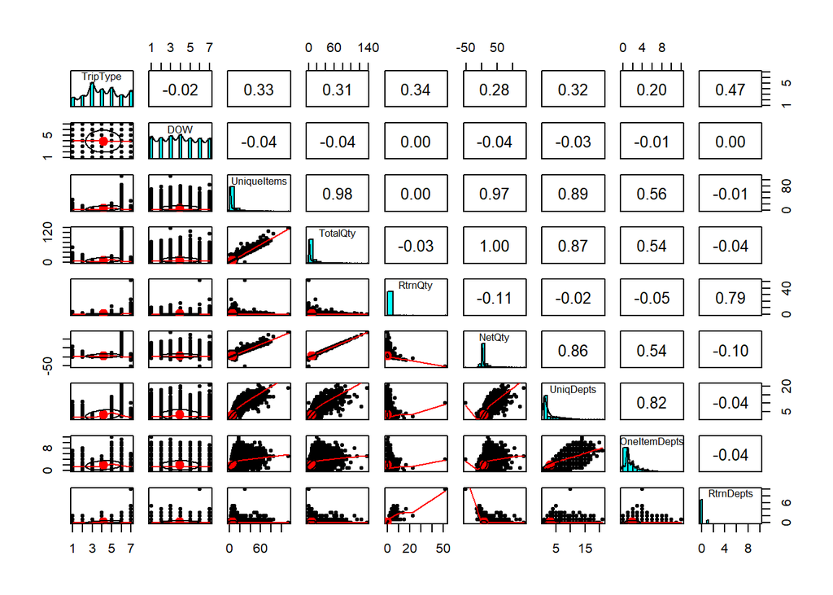

```r
pairs.panels(trips)
```

```r
model <- C5.0(TripType ~ ., data = trips, control = C5.0Control(noGlobalPruning = FALSE, CF = 0.1))
```

```r
summary(model)
```

```
##
## Call:
## C5.0.formula(formula = TripType ~ ., data = trips, control
##  = C5.0Control(noGlobalPruning = FALSE, CF = 0.1))
##
##
## C5.0 [Release 2.07 GPL Edition]      Tue Apr 23 19:00:28 2024
## -------------------------------
##
## Class specified by attribute `outcome'
##
## Read 12734 cases (9 attributes) from undefined.data
##
## Decision tree:
##
## NetQty <= 3:
## :...NetQty <= 0: 999 (1345)
## :   NetQty > 0: 8 (6660/3899)
## NetQty > 3:
## :...NetQty > 19: 40 (1377/59)
##     NetQty <= 19:
##     :...UniqDepts > 2: 39 (2901/820)
##         UniqDepts <= 2:
##         :...UniqueItems <= 1: 5 (42/17)
##             UniqueItems > 1:
##             :...TotalQty <= 5: 7 (252/154)
##                 TotalQty > 5: 39 (157/106)
##
##
## Evaluation on training data (12734 cases):
##
##      Decision Tree
##    ----------------
##    Size      Errors
##
##       7 5055(39.7%)   <<
##
##
##     (a)   (b)   (c)   (d)   (e)   (f)   (g)    <-classified as
##    ----  ----  ----  ----  ----  ----  ----
##      25    60   763         246    12          (a): class 5
##       7    98   674         522     4          (b): class 7
##            25  2761          22                (c): class 8
##            11  2020          15                (d): class 9
##       8    39     7        2132    43          (e): class 39
##             1                54  1318          (f): class 40
##       2    18   435          67        1345    (g): class 999
##
##
##  Attribute usage:
##
##  100.00% NetQty
##   26.32% UniqDepts
##    3.54% UniqueItems
##    3.21% TotalQty
##
##
## Time: 0.0 secs
```

# Code chunk 2 - Use SimpleKMeans clustering to understand visits (42 points)

## a. Save the number of unique TripType in the imported data as TripType.levels. Remove TripType from input data.

```r
# Save the number of unique TripType levels
TripType.levels <- length(unique(trips$TripType))

# Remove TripType from the input data
trips <- trips[, !(names(trips) %in% c("TripType"))]
str(trips)
```

```
## 'data.frame':    12734 obs. of  8 variables:
##  $ DOW         : Factor w/ 7 levels "Friday","Monday",..: 1 1 1 1 1 1 1 1 1 1 ...
##  $ UniqueItems : int  1 2 1 1 2 1 1 1 1 1 ...
##  $ TotalQty    : int  0 1 0 0 3 0 0 0 1 0 ...
##  $ RtrnQty     : int  1 1 1 1 0 1 1 1 0 1 ...
##  $ NetQty      : int  -1 0 -1 -1 3 -1 -1 -1 1 -1 ...
##  $ UniqDepts   : int  1 1 1 1 2 1 1 1 1 1 ...
##  $ OneItemDepts: int  1 0 1 1 2 1 1 1 1 1 ...
##  $ RtrnDepts   : int  1 1 1 1 0 1 1 1 0 1 ...
```

## b. Generate clusters with the default (i.e. random) initial cluster assignment and the default distance function (Euclidean). The number of clusters equals to TripType.levels. Show the clustering information with the standard deviations and the centroids of the clusters.

```r
set.seed(123)
# Set the number of clusters to the value stored in TripType.levels and use random initialization
trips_kmeans <- SimpleKMeans(trips, Weka_control(N=TripType.levels, init=0, V=TRUE))

trips_kmeans
```

```
##
## kMeans
## ======
##
## Number of iterations: 14
## Within cluster sum of squared errors: 3983.3256867784276
##
## Initial starting points (random):
##
## Cluster 0: Friday,4,0,4,-4,2,1,2
## Cluster 1: Wednesday,2,2,0,2,2,2,0
## Cluster 2: Thursday,1,0,1,-1,1,1,1
## Cluster 3: Wednesday,1,1,0,1,1,1,0
## Cluster 4: Sunday,1,1,1,0,1,1,1
## Cluster 5: Saturday,5,5,0,5,3,2,0
## Cluster 6: Friday,4,4,0,4,4,4,0
##
## Missing values globally replaced with mean/mode
##
## Final cluster centroids:
##                               Cluster#
## Attribute        Full Data           0           1           2           3           4           5           6
##                  (12734.0)    (1926.0)     (795.0)    (2359.0)    (2838.0)    (2319.0)    (1982.0)     (515.0)
## ==============================================================================================================
## DOW                 Sunday      Friday   Wednesday    Thursday   Wednesday      Sunday    Saturday      Friday
##   Friday       1851.0 ( 14%)1569.0 ( 81%)  0.0 (  0%)  0.0 (  0%)  0.0 (  0%)  0.0 (  0%)  0.0 (  0%)282.0 ( 54%)
##   Monday       1765.0 ( 13%)187.0 (  9%)216.0 ( 27%)320.0 ( 13%)707.0 ( 24%)158.0 (  6%) 35.0 (  1%)142.0 ( 27%)
##   Saturday     1923.0 ( 15%)  0.0 (  0%)  0.0 (  0%)  0.0 (  0%)  0.0 (  0%)  0.0 (  0%)1922.0 ( 96%)  1.0 (  0%)
##   Sunday       2014.0 ( 15%)  0.0 (  0%)  0.0 (  0%)  0.0 (  0%)  0.0 (  0%)2014.0 ( 86%)  0.0 (  0%)  0.0 (  0%)
##   Thursday     1738.0 ( 13%)  0.0 (  0%)  0.0 (  0%)1737.0 ( 73%)  0.0 (  0%)  0.0 (  0%)  0.0 (  0%)  1.0 (  0%)
##   Tuesday      1703.0 ( 13%)170.0 (  8%)210.0 ( 26%)302.0 ( 12%)760.0 ( 26%)147.0 (  6%) 25.0 (  1%) 89.0 ( 17%)
##   Wednesday    1740.0 ( 13%)  0.0 (  0%)369.0 ( 46%)  0.0 (  0%)1371.0 ( 48%)  0.0 (  0%)  0.0 (  0%)  0.0 (  0%)
##
## UniqueItems         6.2033      2.6651     14.1799      4.7512      2.0247      7.9461      6.7735     26.7592
##                  +/-9.1936   +/-2.8401   +/-8.4465   +/-7.3608   +/-1.6575  +/-10.1846    +/-9.323  +/-14.0425
##
## TotalQty            7.1849      2.8411     16.7157      5.5019      2.1945      9.2902      7.8158     32.0175
##                 +/-11.2831     +/-3.91  +/-10.7118   +/-9.3125   +/-2.2108   +/-12.458  +/-11.3376  +/-17.2611
##
## RtrnQty             0.2431      0.4361      0.2113       0.178      0.1853       0.229      0.2619      0.1786
##                  +/-0.9149   +/-0.9064   +/-1.9588   +/-0.5966   +/-0.8215    +/-0.808   +/-0.8843   +/-0.4783
##
## NetQty              6.9417       2.405     16.5044      5.3239      2.0092      9.0612       7.554     31.8388
##                 +/-11.3513   +/-4.1859  +/-10.9241   +/-9.3264   +/-2.3983  +/-12.5132  +/-11.4112  +/-17.1912
##
## UniqDepts           3.1938       1.812      7.2327      2.7897      1.4137      3.8482      3.4026     10.0369
##                  +/-3.0952   +/-1.2409   +/-2.0374   +/-2.4401   +/-0.7464   +/-3.2775   +/-3.1987   +/-2.6882
##
## OneItemDepts        1.9179      1.3032      4.2264      1.9262      0.9683      2.1458      1.9581       4.666
##                  +/-1.6439   +/-0.9011   +/-1.4281   +/-1.3618   +/-0.6762    +/-1.669   +/-1.6589   +/-2.0273
##
## RtrnDepts           0.1756      0.3344       0.122      0.1412      0.1163      0.1686      0.1821      0.1553
##                  +/-0.4553   +/-0.5473   +/-0.5254   +/-0.4035    +/-0.358   +/-0.4686    +/-0.473   +/-0.3935
```

```r
set.seed(123)
trips_kmeans2 <- SimpleKMeans(trips, Weka_control(N=TripType.levels, init=2, V=TRUE))

# Print the clustering results
trips_kmeans2
```

```
##
## kMeans
## ======
##
## Number of iterations: 2
## Within cluster sum of squared errors: 787.2085533735577
##
## Initial starting points (canopy):
##
## T2 radius: 0.735
## T1 radius: 0.918
##
## Cluster 0: Saturday,6.520627,7.496606,0.256397,7.240209,3.344648,1.965013,0.179634,{1915} <0>
## Cluster 1: Sunday,5.866912,6.731194,0.235139,6.496055,3.171489,1.904261,0.173067,{1901} <1>
## Cluster 2: Friday,4.990044,5.815265,0.221792,5.593473,2.775442,1.732854,0.160951,{1808} <2>
## Cluster 3: Wednesday,5.061778,5.773672,0.236143,5.537529,2.872402,1.82448,0.17321,{1732} <3>
## Cluster 4: Thursday,4.950408,5.711785,0.226954,5.484831,2.802217,1.786464,0.177946,{1714} <4>
## Cluster 5: Tuesday,5.248968,6.025369,0.227729,5.79764,2.905605,1.827139,0.158112,{1695} <5>
## Cluster 6: Monday,5.145895,5.949793,0.249262,5.700532,2.890136,1.802717,0.182516,{1693} <6>
##
##
## Missing values globally replaced with mean/mode
##
## Final cluster centroids:
##                               Cluster#
## Attribute        Full Data           0           1           2           3           4           5           6
##                  (12734.0)    (1923.0)    (2014.0)    (1851.0)    (1740.0)    (1738.0)    (1703.0)    (1765.0)
## ==============================================================================================================
## DOW                 Sunday    Saturday      Sunday      Friday   Wednesday    Thursday     Tuesday      Monday
##   Friday       1851.0 ( 14%)  0.0 (  0%)  0.0 (  0%)1851.0 (100%)  0.0 (  0%)  0.0 (  0%)  0.0 (  0%)  0.0 (  0%)
##   Monday       1765.0 ( 13%)  0.0 (  0%)  0.0 (  0%)  0.0 (  0%)  0.0 (  0%)  0.0 (  0%)  0.0 (  0%)1765.0 (100%)
##   Saturday     1923.0 ( 15%)1923.0 (100%)  0.0 (  0%)  0.0 (  0%)  0.0 (  0%)  0.0 (  0%)  0.0 (  0%)  0.0 (  0%)
##   Sunday       2014.0 ( 15%)  0.0 (  0%)2014.0 (100%)  0.0 (  0%)  0.0 (  0%)  0.0 (  0%)  0.0 (  0%)  0.0 (  0%)
##   Thursday     1738.0 ( 13%)  0.0 (  0%)  0.0 (  0%)  0.0 (  0%)  0.0 (  0%)1738.0 (100%)  0.0 (  0%)  0.0 (  0%)
##   Tuesday      1703.0 ( 13%)  0.0 (  0%)  0.0 (  0%)  0.0 (  0%)  0.0 (  0%)  0.0 (  0%)1703.0 (100%)  0.0 (  0%)
##   Wednesday    1740.0 ( 13%)  0.0 (  0%)  0.0 (  0%)  0.0 (  0%)1740.0 (100%)  0.0 (  0%)  0.0 (  0%)  0.0 (  0%)
##
## UniqueItems         6.2033      6.7894      7.7066      5.7736       5.296       5.538      5.4839      6.5439
##                  +/-9.1936   +/-9.7603  +/-10.7485   +/-8.5904   +/-7.8033   +/-8.5521   +/-8.1858   +/-9.7657
##
## TotalQty            7.1849      7.8248       8.922      6.7634      6.0575      6.4764      6.2959      7.6142
##                 +/-11.2831  +/-11.8634  +/-13.0421  +/-10.6401   +/-9.5957  +/-10.9471   +/-9.9807  +/-11.8781
##
## RtrnQty             0.2431      0.2579      0.2423       0.222      0.2379      0.2307       0.259      0.2521
##                  +/-0.9149   +/-0.8644   +/-0.8231   +/-0.7135   +/-0.9047   +/-0.6686   +/-1.4742   +/-0.7585
##
## NetQty              6.9417      7.5668      8.6797      6.5413      5.8195      6.2457       6.037       7.362
##                 +/-11.3513  +/-11.9357  +/-13.0922  +/-10.7088    +/-9.642  +/-10.9675  +/-10.1714  +/-11.9312
##
## UniqDepts           3.1938      3.4041      3.7115       3.013       2.931      2.9413      2.9571      3.2997
##                  +/-3.0952   +/-3.2653   +/-3.4818   +/-2.9741   +/-2.8278   +/-2.8288   +/-2.8278   +/-3.2188
##
## OneItemDepts        1.9179      1.9823      2.1018      1.8293      1.8402      1.8349      1.8426      1.9615
##                  +/-1.6439   +/-1.6761   +/-1.7462   +/-1.6318    +/-1.554   +/-1.5575    +/-1.622   +/-1.6717
##
## RtrnDepts           0.1756       0.181      0.1783      0.1621      0.1753      0.1818       0.165      0.1853
##                  +/-0.4553   +/-0.4703   +/-0.4702    +/-0.427   +/-0.4509   +/-0.4454   +/-0.4754   +/-0.4444
```

```r
set.seed(123)
trips_kmeans3 <- SimpleKMeans(trips, Weka_control(N=TripType.levels, init=2, A ="weka.core.ManhattanDistance", V=TRUE))

# Print the clustering results
trips_kmeans3
```

```
##
## kMeans
## ======
##
## Number of iterations: 2
## Sum of within cluster distances: 4319.921389839508
##
## Initial starting points (canopy):
##
## T2 radius: 0.735
## T1 radius: 0.918
##
## Cluster 0: Saturday,6.520627,7.496606,0.256397,7.240209,3.344648,1.965013,0.179634,{1915} <0>
## Cluster 1: Sunday,5.866912,6.731194,0.235139,6.496055,3.171489,1.904261,0.173067,{1901} <1>
## Cluster 2: Friday,4.990044,5.815265,0.221792,5.593473,2.775442,1.732854,0.160951,{1808} <2>
## Cluster 3: Wednesday,5.061778,5.773672,0.236143,5.537529,2.872402,1.82448,0.17321,{1732} <3>
## Cluster 4: Thursday,4.950408,5.711785,0.226954,5.484831,2.802217,1.786464,0.177946,{1714} <4>
## Cluster 5: Tuesday,5.248968,6.025369,0.227729,5.79764,2.905605,1.827139,0.158112,{1695} <5>
## Cluster 6: Monday,5.145895,5.949793,0.249262,5.700532,2.890136,1.802717,0.182516,{1693} <6>
##
##
## Missing values globally replaced with mean/mode
##
## Final cluster centroids:
##                               Cluster#
## Attribute        Full Data           0           1           2           3           4           5           6
##                  (12734.0)    (1923.0)    (2014.0)    (1851.0)    (1740.0)    (1738.0)    (1703.0)    (1765.0)
## ==============================================================================================================
## DOW                 Sunday    Saturday      Sunday      Friday   Wednesday    Thursday     Tuesday      Monday
##   Friday       1851.0 ( 14%)  0.0 (  0%)  0.0 (  0%)1851.0 (100%)  0.0 (  0%)  0.0 (  0%)  0.0 (  0%)  0.0 (  0%)
##   Monday       1765.0 ( 13%)  0.0 (  0%)  0.0 (  0%)  0.0 (  0%)  0.0 (  0%)  0.0 (  0%)  0.0 (  0%)1765.0 (100%)
##   Saturday     1923.0 ( 15%)1923.0 (100%)  0.0 (  0%)  0.0 (  0%)  0.0 (  0%)  0.0 (  0%)  0.0 (  0%)  0.0 (  0%)
##   Sunday       2014.0 ( 15%)  0.0 (  0%)2014.0 (100%)  0.0 (  0%)  0.0 (  0%)  0.0 (  0%)  0.0 (  0%)  0.0 (  0%)
##   Thursday     1738.0 ( 13%)  0.0 (  0%)  0.0 (  0%)  0.0 (  0%)  0.0 (  0%)1738.0 (100%)  0.0 (  0%)  0.0 (  0%)
##   Tuesday      1703.0 ( 13%)  0.0 (  0%)  0.0 (  0%)  0.0 (  0%)  0.0 (  0%)  0.0 (  0%)1703.0 (100%)  0.0 (  0%)
##   Wednesday    1740.0 ( 13%)  0.0 (  0%)  0.0 (  0%)  0.0 (  0%)1740.0 (100%)  0.0 (  0%)  0.0 (  0%)  0.0 (  0%)
##
## UniqueItems              2           2           3           2           2           2           2           2
##                  +/-9.1936   +/-9.7603  +/-10.7485   +/-8.5904   +/-7.8033   +/-8.5521   +/-8.1858   +/-9.7657
##
## TotalQty                 3           3           3           2           2           2           2           2
##                 +/-11.2831  +/-11.8634  +/-13.0421  +/-10.6401   +/-9.5957  +/-10.9471   +/-9.9807  +/-11.8781
##
## RtrnQty                  0           0           0           0           0           0           0           0
##                  +/-0.9149   +/-0.8644   +/-0.8231   +/-0.7135   +/-0.9047   +/-0.6686   +/-1.4742   +/-0.7585
##
## NetQty                   2           3           3           2           2           2           2           2
##                 +/-11.3513  +/-11.9357  +/-13.0922  +/-10.7088    +/-9.642  +/-10.9675  +/-10.1714  +/-11.9312
##
## UniqDepts                2           2           2           2           2           2           2           2
##                  +/-3.0952   +/-3.2653   +/-3.4818   +/-2.9741   +/-2.8278   +/-2.8288   +/-2.8278   +/-3.2188
##
## OneItemDepts             1           1           2           1           1           1           1           1
##                  +/-1.6439   +/-1.6761   +/-1.7462   +/-1.6318    +/-1.554   +/-1.5575    +/-1.622   +/-1.6717
##
## RtrnDepts                0           0           0           0           0           0           0           0
##                  +/-0.4553   +/-0.4703   +/-0.4702    +/-0.427   +/-0.4509   +/-0.4454   +/-0.4754   +/-0.4444
```

## d. Choose your own distance function and initial cluster assignment method, increase or decrease the number of clusters. Cluster the visits again and show the standard deviations and the centroids of the clusters.

```r
set.seed(123)

new_cluster_count <- round(TripType.levels * 1.2)

trips_kmeans4 <- SimpleKMeans(trips, Weka_control(N=new_cluster_count, init=2, A ="weka.core.ManhattanDistance", V=TRUE))

trips_kmeans4
```

```
##
## kMeans
## ======
##
## Number of iterations: 8
## Sum of within cluster distances: 3940.365619940344
##
## Initial starting points (canopy):
##
## T2 radius: 0.735
## T1 radius: 0.918
##
## Cluster 0: Saturday,6.520627,7.496606,0.256397,7.240209,3.344648,1.965013,0.179634,{1915} <0>
## Cluster 1: Sunday,5.866912,6.731194,0.235139,6.496055,3.171489,1.904261,0.173067,{1901} <1,7>
## Cluster 2: Friday,4.990044,5.815265,0.221792,5.593473,2.775442,1.732854,0.160951,{1808} <2>
## Cluster 3: Wednesday,5.061778,5.773672,0.236143,5.537529,2.872402,1.82448,0.17321,{1732} <3>
## Cluster 4: Thursday,4.950408,5.711785,0.226954,5.484831,2.802217,1.786464,0.177946,{1714} <4>
## Cluster 5: Tuesday,5.248968,6.025369,0.227729,5.79764,2.905605,1.827139,0.158112,{1695} <5>
## Cluster 6: Monday,5.145895,5.949793,0.249262,5.700532,2.890136,1.802717,0.182516,{1693} <6>
## Cluster 7: Sunday,38.285714,45.410714,0.366071,45.044643,12.732143,5.410714,0.267857,{112} <1,7>
##
##
## Missing values globally replaced with mean/mode
##
## Final cluster centroids:
##                               Cluster#
## Attribute        Full Data           0           1           2           3           4           5           6           7
##                  (12734.0)    (1825.0)    (1596.0)    (1777.0)    (1691.0)    (1681.0)    (1651.0)    (1688.0)     (825.0)
## ==========================================================================================================================
## DOW                 Sunday    Saturday      Sunday      Friday   Wednesday    Thursday     Tuesday      Monday      Sunday
##   Friday       1851.0 ( 14%)  0.0 (  0%)  0.0 (  0%)1777.0 (100%)  0.0 (  0%)  0.0 (  0%)  0.0 (  0%)  0.0 (  0%) 74.0 (  8%)
##   Monday       1765.0 ( 13%)  0.0 (  0%)  0.0 (  0%)  0.0 (  0%)  0.0 (  0%)  0.0 (  0%)  0.0 (  0%)1688.0 (100%) 77.0 (  9%)
##   Saturday     1923.0 ( 15%)1825.0 (100%)  0.0 (  0%)  0.0 (  0%)  0.0 (  0%)  0.0 (  0%)  0.0 (  0%)  0.0 (  0%) 98.0 ( 11%)
##   Sunday       2014.0 ( 15%)  0.0 (  0%)1596.0 (100%)  0.0 (  0%)  0.0 (  0%)  0.0 (  0%)  0.0 (  0%)  0.0 (  0%)418.0 ( 50%)
##   Thursday     1738.0 ( 13%)  0.0 (  0%)  0.0 (  0%)  0.0 (  0%)  0.0 (  0%)1681.0 (100%)  0.0 (  0%)  0.0 (  0%) 57.0 (  6%)
##   Tuesday      1703.0 ( 13%)  0.0 (  0%)  0.0 (  0%)  0.0 (  0%)  0.0 (  0%)  0.0 (  0%)1651.0 (100%)  0.0 (  0%) 52.0 (  6%)
##   Wednesday    1740.0 ( 13%)  0.0 (  0%)  0.0 (  0%)  0.0 (  0%)1691.0 (100%)  0.0 (  0%)  0.0 (  0%)  0.0 (  0%) 49.0 (  5%)
##
## UniqueItems              2           2           2           2           2           2           2           2          26
##                  +/-9.1936    +/-6.622   +/-3.4343     +/-6.38   +/-6.0338    +/-6.356   +/-6.2806   +/-6.8107  +/-13.9136
##
## TotalQty                 3           2           2           2           2           2           2           2          31
##                 +/-11.2831   +/-8.2988   +/-4.3348   +/-8.0467    +/-7.552   +/-8.2405   +/-7.8886   +/-8.6048  +/-17.2505
##
## RtrnQty                  0           0           0           0           0           0           0           0           0
##                  +/-0.9149   +/-0.8779   +/-0.8714   +/-0.7194   +/-0.9137   +/-0.6596   +/-1.4933   +/-0.7651   +/-0.6121
##
## NetQty                   2           2           2           2           2           2           2           2          31
##                 +/-11.3513   +/-8.4082   +/-4.5068    +/-8.146    +/-7.616   +/-8.3028   +/-8.1314   +/-8.6881  +/-17.1666
##
## UniqDepts                2           2           2           2           2           2           2           2          11
##                  +/-3.0952   +/-2.5462   +/-1.5556   +/-2.3558   +/-2.3573   +/-2.2802   +/-2.3145   +/-2.5065   +/-2.6926
##
## OneItemDepts             1           1           1           1           1           1           1           1           5
##                  +/-1.6439   +/-1.4805   +/-1.1071   +/-1.4415   +/-1.4126   +/-1.3885   +/-1.4579    +/-1.476   +/-1.7711
##
## RtrnDepts                0           0           0           0           0           0           0           0           0
##                  +/-0.4553   +/-0.4739   +/-0.4858   +/-0.4258   +/-0.4526   +/-0.4382   +/-0.4769   +/-0.4443   +/-0.4316
```

# Code Chunk 3 - Market Basket Analysis with the Walmart dept baskets

## a. (7 points) Import Walmart_baskets_1week.csv Download Walmart_baskets_1week.csvusing the following read.transactions() with the “single” format (for long format) and save it in a sparse matrix called, e.g., Dept_baskets.

```r
Dept_baskets <- read.transactions("Walmart_baskets_1week.csv", format="single", sep = ",", header = TRUE, cols=c("VisitNumber","DepartmentDescription"))
```

## b. Inspect the first 15 transactions.

```r
# Inspecting the first 15 transactions
inspect(Dept_baskets[1:15])
```

```
##      items                         transactionID
## [1]  {IMPULSE MERCHANDISE}                 10009
## [2]  {CANDY, TOBACCO, COOKIES,
##       HOME MANAGEMENT,
##       JEWELRY AND SUNGLASSES,
##       MENS WEAR}                           10034
## [3]  {GIRLS WEAR, 4-6X  AND 7-14,
##       GROCERY DRY GOODS,
##       IMPULSE MERCHANDISE,
##       PERSONAL CARE}                       10051
## [4]  {OTHER DEPARTMENTS}                   10118
## [5]  {FINANCIAL SERVICES}                  10167
## [6]  {DAIRY,
##       DSD GROCERY,
##       FROZEN FOODS,
##       GROCERY DRY GOODS,
##       MEAT - FRESH & FROZEN,
##       PERSONAL CARE,
##       PRE PACKED DELI,
##       SLEEPWEAR/FOUNDATIONS}               10178
## [7]  {PHARMACY OTC}                        10191
## [8]  {FINANCIAL SERVICES}                  10206
## [9]  {INFANT CONSUMABLE HARDLINES}         1022
## [10] {CELEBRATION,
##       FABRICS AND CRAFTS,
##       OFFICE SUPPLIES,
##       TOYS}                                10250
## [11] {PHARMACY OTC}                        10272
## [12] {FABRICS AND CRAFTS,
##       GROCERY DRY GOODS,
##       PRODUCE}                             10273
## [13] {SERVICE DELI}                        1029
## [14] {BEAUTY,
##       DSD GROCERY,
##       GROCERY DRY GOODS,
##       HOME DECOR,
##       HOME MANAGEMENT,
##       HOUSEHOLD CHEMICALS/SUPP,
##       HOUSEHOLD PAPER GOODS,
##       LAWN AND GARDEN,
##       PAINT AND ACCESSORIES,
##       PERSONAL CARE,
##       PETS AND SUPPLIES}                   10296
## [15] {BEAUTY}                              10302
```

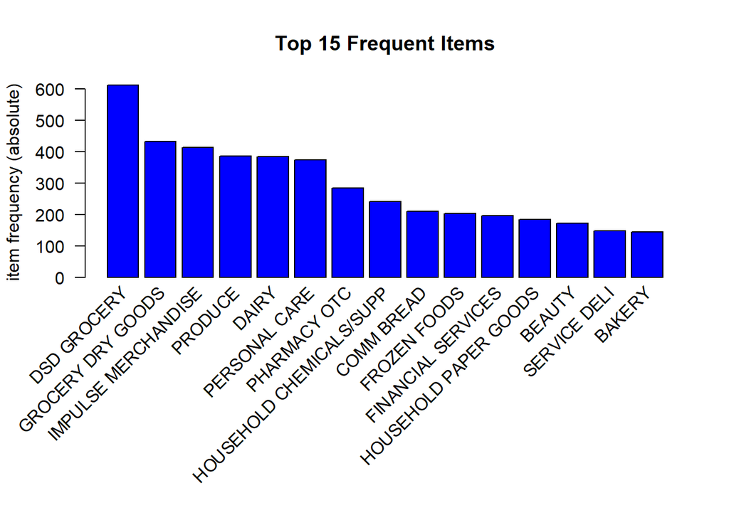

```r
# Plot the most frequent 15 items
itemFrequencyPlot(Dept_baskets, topN = 15, type = "absolute", main = "Top 15 Frequent Items", col = "blue", las = 2)
```

## D. (20 points) Associate rule minin

### i. Use the apriori command to generate about 50 to 100 association rules from the input data. Set your own minimum support and confidence threshold levels. Remember if the thresholds are too low, you will generate more rules than desired, or if you set them too high, you may not generate any or a sufficient number of rules. Show the rules in the descending order of their lift values.

```r
rules <- apriori(Dept_baskets,
                 parameter = list(supp = 0.01, conf = 0.1, target = "rules", minlen = 2),
                 control = list(verbose = FALSE))
# Sorting the rules by lift in descending order
rules_sorted_by_lift <- sort(rules, by = "lift", decreasing = TRUE)

# top rules
inspect(head(rules_sorted_by_lift, n = 100))
```

```
##       lhs                              rhs                           support confidence coverage      lift count
## [1]   {DAIRY,
##        FROZEN FOODS,
##        MEAT - FRESH & FROZEN}       => {PRE PACKED DELI}              0.0140  0.6511628   0.0215 11.947941    28
## [2]   {DAIRY,
##        DSD GROCERY,
##        FROZEN FOODS,
##        MEAT - FRESH & FROZEN}       => {PRE PACKED DELI}              0.0125  0.6410256   0.0195 11.761938    25
## [3]   {FROZEN FOODS,
##        MEAT - FRESH & FROZEN}       => {PRE PACKED DELI}              0.0150  0.6382979   0.0235 11.711888    30
## [4]   {DSD GROCERY,
##        FROZEN FOODS,
##        MEAT - FRESH & FROZEN}       => {PRE PACKED DELI}              0.0135  0.6279070   0.0215 11.521229    27
## [5]   {FROZEN FOODS,
##        PRODUCE}                     => {SEAFOOD}                      0.0110  0.2095238   0.0525 11.325611    22
## [6]   {FROZEN FOODS,
##        MEAT - FRESH & FROZEN,
##        PRODUCE}                     => {PRE PACKED DELI}              0.0125  0.6097561   0.0205 11.188185    25
## [7]   {DAIRY,
##        FROZEN FOODS,
##        MEAT - FRESH & FROZEN,
##        PRODUCE}                     => {PRE PACKED DELI}              0.0115  0.6052632   0.0190 11.105746    23
## [8]   {DSD GROCERY,
##        FROZEN FOODS,
##        MEAT - FRESH & FROZEN,
##        PRODUCE}                     => {PRE PACKED DELI}              0.0115  0.6052632   0.0190 11.105746    23
## [9]   {DAIRY,
##        FROZEN FOODS,
##        GROCERY DRY GOODS,
##        MEAT - FRESH & FROZEN}       => {PRE PACKED DELI}              0.0115  0.6052632   0.0190 11.105746    23
## [10]  {DAIRY,
##        DSD GROCERY,
##        FROZEN FOODS,
##        MEAT - FRESH & FROZEN,
##        PRODUCE}                     => {PRE PACKED DELI}              0.0105  0.6000000   0.0175 11.009174    21
## [11]  {DAIRY,
##        DSD GROCERY,
##        FROZEN FOODS,
##        GROCERY DRY GOODS,
##        MEAT - FRESH & FROZEN}       => {PRE PACKED DELI}              0.0100  0.5882353   0.0170 10.793308    20
```

[output cut: 315 more lines]

```
##        DSD GROCERY,
##        FROZEN FOODS,
##        PRODUCE}                     => {MEAT - FRESH & FROZEN}        0.0115  0.5111111   0.0225  8.177778    23
## [98]  {COMM BREAD,
##        DSD GROCERY,
##        FROZEN FOODS,
##        GROCERY DRY GOODS,
##        PRODUCE}                     => {MEAT - FRESH & FROZEN}        0.0115  0.5111111   0.0225  8.177778    23
## [99]  {COMM BREAD,
##        DSD GROCERY,
##        FROZEN FOODS,
##        PRODUCE}                     => {MEAT - FRESH & FROZEN}        0.0120  0.5106383   0.0235  8.170213    24
## [100] {COMM BREAD,
##        DSD GROCERY,
##        PRE PACKED DELI}             => {MEAT - FRESH & FROZEN}        0.0130  0.5098039   0.0255  8.156863    26
```

### ii. Similar to the last task, use the apriori command now to generate about 100 - 200 association rules from the input data. Set your own minimum support and confidence threshold levels. Show the rules in the descending order of their lift values.

```r
rules2 <- apriori(Dept_baskets,
                 parameter = list(supp = 0.005, conf = 0.05, target = "rules", minlen = 2),
                 control = list(verbose = FALSE))

# Sorting the rules by lift in descending order
rules_sorted_by_lift2 <- sort(rules2, by = "lift", decreasing = TRUE)

# Inspecting the top rules
inspect(head(rules_sorted_by_lift2, n = 120))
```

```
##       lhs                               rhs                       support confidence coverage     lift count
## [1]   {DSD GROCERY,
##        FROZEN FOODS,
##        GROCERY DRY GOODS,
##        MEAT - FRESH & FROZEN,
##        PRODUCE}                      => {SEAFOOD}                  0.0055  0.3437500   0.0160 18.58108    11
## [2]   {FROZEN FOODS,
##        GROCERY DRY GOODS,
##        MEAT - FRESH & FROZEN,
##        PRODUCE}                      => {SEAFOOD}                  0.0060  0.3428571   0.0175 18.53282    12
## [3]   {DAIRY,
##        FROZEN FOODS,
##        GROCERY DRY GOODS,
##        MEAT - FRESH & FROZEN,
##        PRODUCE}                      => {SEAFOOD}                  0.0055  0.3333333   0.0165 18.01802    11
## [4]   {DAIRY,
##        DSD GROCERY,
##        FROZEN FOODS,
##        GROCERY DRY GOODS,
##        MEAT - FRESH & FROZEN,
##        PRODUCE}                      => {SEAFOOD}                  0.0050  0.3333333   0.0150 18.01802    10
## [5]   {FROZEN FOODS,
##        MEAT - FRESH & FROZEN,
##        PRODUCE}                      => {SEAFOOD}                  0.0065  0.3170732   0.0205 17.13909    13
## [6]   {DAIRY,
##        FROZEN FOODS,
##        MEAT - FRESH & FROZEN,
##        PRODUCE}                      => {SEAFOOD}                  0.0060  0.3157895   0.0190 17.06970    12
## [7]   {DSD GROCERY,
##        FROZEN FOODS,
##        MEAT - FRESH & FROZEN,
##        PRODUCE}                      => {SEAFOOD}                  0.0060  0.3157895   0.0190 17.06970    12
## [8]   {DAIRY,
##        DSD GROCERY,
##        FROZEN FOODS,
##        MEAT - FRESH & FROZEN,
##        PRODUCE}                      => {SEAFOOD}                  0.0055  0.3142857   0.0175 16.98842    11
## [9]   {DSD GROCERY,
##        FROZEN FOODS,
##        GROCERY DRY GOODS,
```

[output cut: 422 more lines]

```
##        DSD GROCERY,
##        FROZEN FOODS,
##        HOUSEHOLD PAPER GOODS,
##        MEAT - FRESH & FROZEN}        => {PRE PACKED DELI}          0.0050  0.5882353   0.0085 10.79331    10
## [119] {DAIRY,
##        DSD GROCERY,
##        FROZEN FOODS,
##        GROCERY DRY GOODS,
##        MEAT - FRESH & FROZEN}        => {PRE PACKED DELI}          0.0100  0.5882353   0.0170 10.79331    20
## [120] {DAIRY,
##        DSD GROCERY,
##        FROZEN FOODS,
##        HOUSEHOLD PAPER GOODS,
##        MEAT - FRESH & FROZEN,
##        PRODUCE}                      => {PRE PACKED DELI}          0.0050  0.5882353   0.0085 10.79331    10
```

# Task II Reflections

## 1. What were the minimum support level and the minimum confidence level you selected for the Association Rule Mining tasks? Given these levels, What is the rule with the highest lift given your final choices of these levels? What is the rule with the highest support level? What is the rule with the highest confidence level? Which rule out of these three (or fewer) do you recommend for sales executives to consider? What is the reason for your recommendation?

Based on these findings, the rule with the highest lift is particularly recommended for sales executives to consider for implementation. This rule not only signifies a strong association but also spans across multiple departments, suggesting a broad impact on customer purchasing behavior. By strategically placing seafood promotions or displays near departments such as dsd grocery, frozen foods, and grocery dry goods, stores might enhance the visibility and likelihood of seafood purchases. This approach leverages the natural shopping patterns observed in the data, potentially leading to increased sales and better customer satisfaction by aligning store layouts and promotions with actual consumer behavior.

## 2. What have you learned from building each of these models and the modeling impact of your adjustments to the hyperparameters or dataset? What can you say about the clusters that were formed? Is there anything interesting to point out? Recall clustering is often used to discover latent (hidden) information. What have you discovered? Make sure to discuss the association rule mining results as well.

Increasing the number of clusters by 20% further refined the granularity, separating even more distinct customer behaviors, particularly on weekends. This enhanced breakdown provided a richer understanding of how different segments behave, facilitating more tailored marketing strategies.

Association rule mining with a minimum support of 0.005 and confidence of 0.05 revealed compelling associations, like the one between purchasing groups of DSD Grocery, Frozen Foods, Grocery Dry Goods, Meat - Fresh & Frozen, and Produce and the likelihood of buying Seafood, which had a lift of 18.58108. This suggests that when these items are purchased, Seafood is also likely to be bought, indicating a strategic placement for promotions could increase Seafood sales.

Overall, this analysis uncovered latent patterns in shopping data, offering crucial insights for targeted marketing and sales strategies. By understanding these patterns, businesses can enhance customer satisfaction and optimize their promotional efforts effectively.

## 3. If you were explaining the results of these models to a supervisor what would you say about them? Attempt to do more than just state facts here, interpret the results. Coding is great, interpretation of output is even more important. Discuss each model. Write at least 150 words

I would focus on interpreting the patterns and insights that can drive actionable business decisions.

The association rule mining illuminated purchasing behaviors, uncovering strong relationships between certain categories of items. Notably, the high lift value found between a set of grocery categories and Seafood suggests a cross-selling opportunity. This will inform my supervisor what to pair withg seafood in terms of promotion.

Overall, these models don’t just segment our customer base or predict purchasing patterns; they provide strategic insights that can be leveraged to enhance marketing effectiveness, optimize store layout, and ultimately, drive revenue growth by aligning sales strategies with actual customer behavior.